# TP: Imputation de données manquantes

### 10 (7) Application de la méthode NIPALS

Appliquons NIPALS à paris2005 :

```r
dat.nipals = plsdepot::nipals(dat,comps=2)
```

```r
dat.nipals_5 = plsdepot::nipals(dat_NA_5,comps=2)
dat.nipals_15 = plsdepot::nipals(dat_NA_15,comps=2)
dat.nipals_20 = plsdepot::nipals(dat_NA_20,comps=2)
dat.nipals_25 = plsdepot::nipals(dat_NA_25,comps=2)
dat.nipals_30 = plsdepot::nipals(dat_NA_30,comps=2)
```

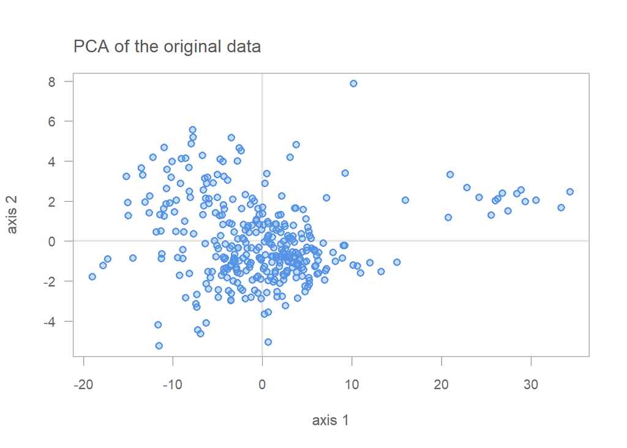

```r
plot(dat.nipals, what="observations", main='PCA of the original data')
```

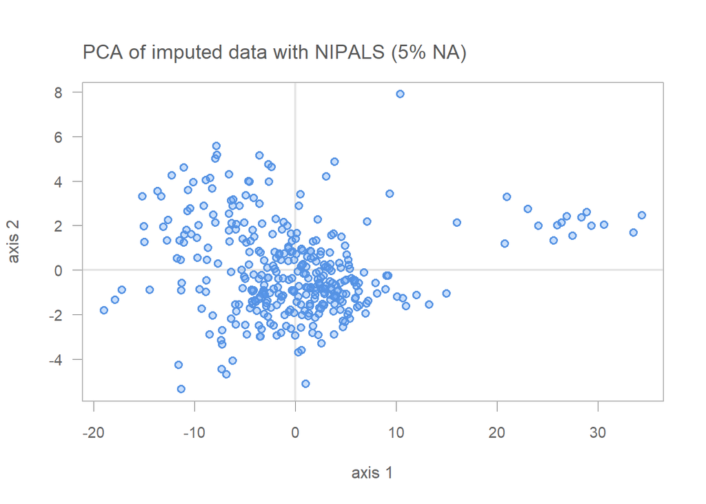

```r
plot(dat.nipals_5, what="observations", main='PCA of imputed data with NIPALS (5% NA)')
```

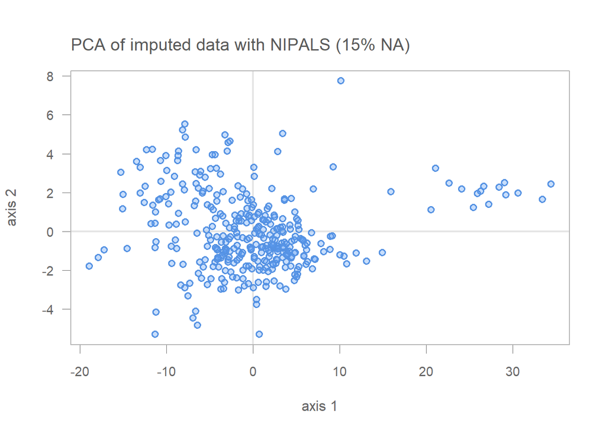

```r
plot(dat.nipals_15, what="observations", main='PCA of imputed data with NIPALS (15% NA)')
```

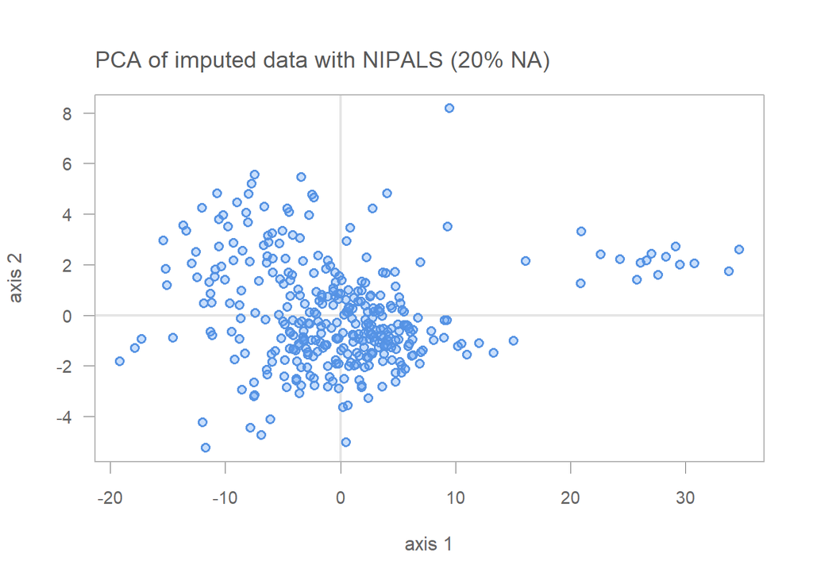

```r
plot(dat.nipals_20, what="observations", main='PCA of imputed data with NIPALS (20% NA)')
```

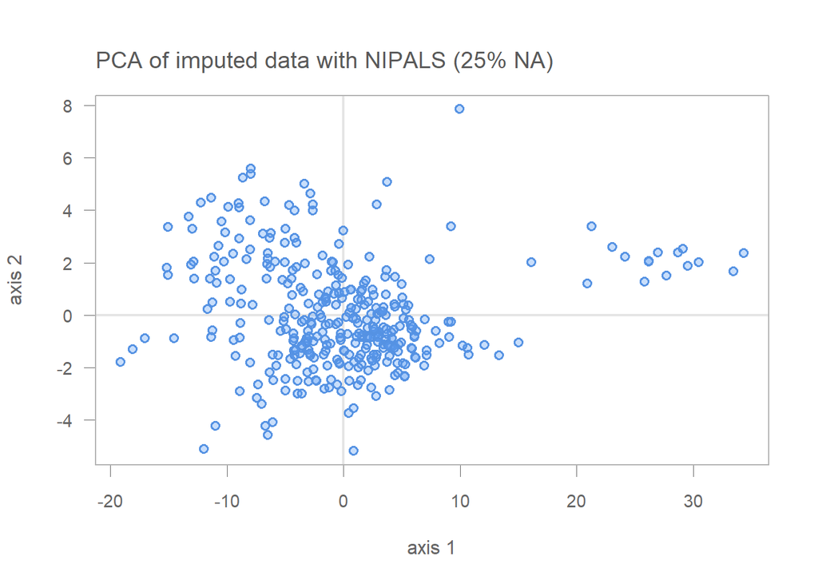

```r
plot(dat.nipals_25, what="observations", main='PCA of imputed data with NIPALS (25% NA)')
```

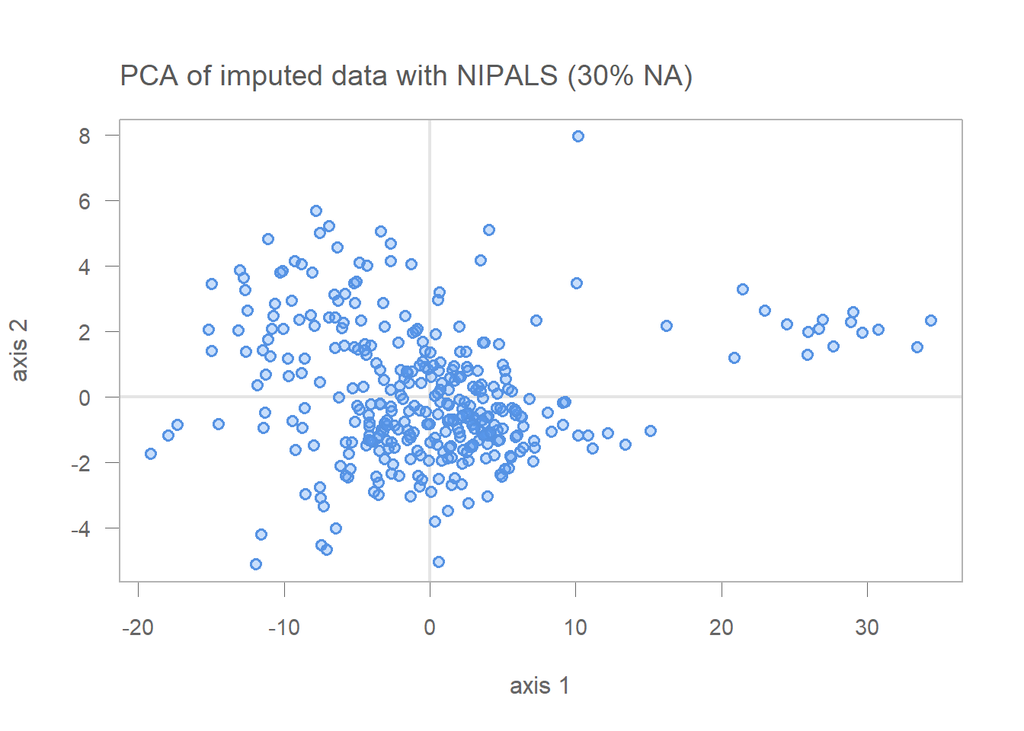

```r
plot(dat.nipals_30, what="observations", main='PCA of imputed data with NIPALS (30% NA)')
```

### 10.(8)-(9)

Comparons la robustesse des différentes imputations pour chacune des méthodes en fonctions des différents pourcentage de valeurs manquantes dans le tableau parris2005

```r
dat_nipals_5 = ade4::nipals(dat_NA_5, nf = 2, rec = TRUE)
# the option rec is needed to obtain the reconstitution of imputed data
# with NIPALS method
dat_nipals_15 = ade4::nipals(dat_NA_15, nf = 2, rec = TRUE)
dat_nipals_20 = ade4::nipals(dat_NA_20, nf = 2, rec = TRUE)
dat_nipals_25 = ade4::nipals(dat_NA_25, nf = 2, rec = TRUE)
dat_nipals_30 = ade4::nipals(dat_NA_30, nf = 2, rec = TRUE)
```

```r
imputation_error <- function(data, data_NA,imputed_data){
  # compute rmse between original values and imputed values on a dataframe
  bool = is.na(data_NA)
  rmse = sqrt(sum((data[bool]-imputed_data[bool])^2))
  return(rmse)
}
```

```r
# hold dataframe in list
NA_data = list(dat_NA_5, dat_NA_15, dat_NA_20,
            dat_NA_25,dat_NA_30)

moy_data = list(dat_moy_5, dat_moy_15, dat_moy_20,
              dat_moy_25,dat_moy_30)

missMDA_data = list(dat_missMDA_5$completeObs, dat_missMDA_15$completeObs,
                    dat_missMDA_20$completeObs,dat_missMDA_25$completeObs,
                    dat_missMDA_30$completeObs)

nipals_data = list(dat_nipals_5$rec, dat_nipals_15$rec,
                   dat_nipals_20$rec, dat_nipals_25$rec,
                   dat_nipals_30$rec)
```

Calculs des différentes erreurs :

```r
err.moy = c()
err.missMDA = c()
err.nipals = c()
for (i in 1:5){
  err.moy = c(err.moy, imputation_error(dat,NA_data[[i]],moy_data[[i]]))
  err.missMDA = append(err.missMDA,
                       imputation_error(dat,NA_data[[i]],missMDA_data[[i]]))
  err.nipals = append(err.nipals,
                      imputation_error(dat,NA_data[[i]],nipals_data[[i]]))
}
```

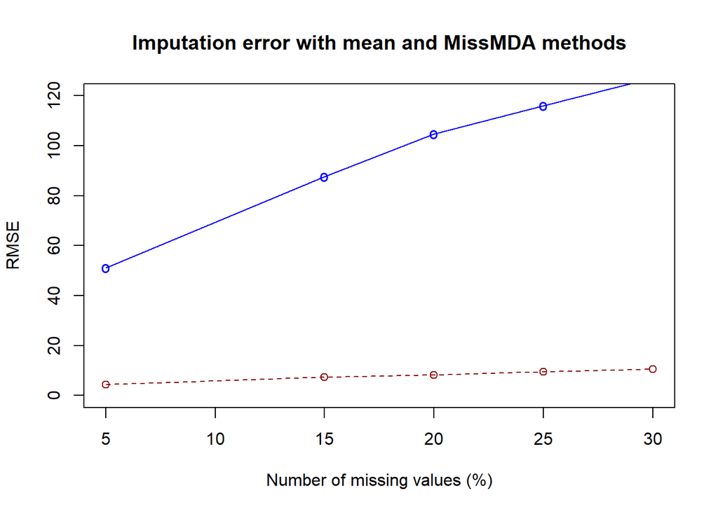

```r
xdata = c(5,15,20,25,30)

# plot the first curve by calling plot() function
# First curve is plotted
plot(xdata, err.moy, type="o", col="blue", pch="o",
     lty=1, ylim=c(0,120), ylab="RMSE", xlab='Number of missing values (%)')

# Add second curve to the same plot by calling points() and lines()
# Use symbol '*' for points.
#lines(xdata, err.nipals, col="red",lty=2)

# Add Third curve to the same plot by calling points() and lines()
# Use symbol '+' for points.
lines(xdata, err.missMDA, type="o", col="dark red", lty=2)

# Adding a legend inside box at the location (2,40) in graph coordinates.
# Note that the order of plots are maintained in the vectors of attributes.
legend(5,150,legend=c("Mean","MissMDA"), col=c("blue","dark red"),
                                   pch=c("o","o"),lty=c(1,2), ncol=1)
title(main='Imputation error with mean and MissMDA methods')
```

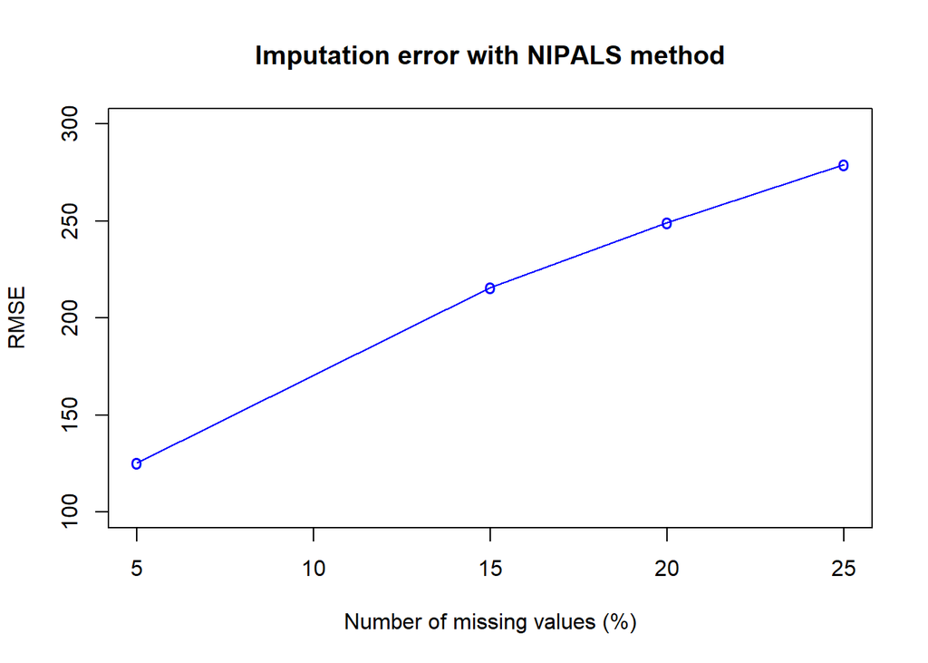

```r
plot(xdata[-5], err.nipals[-5], type="o", col="blue",
     pch="o", lty=1, ylim=c(100,300), ylab="RMSE", xlab='Number of missing values (%)' )
title(main='Imputation error with NIPALS method')
```

```r
percentage_missingvalues <- c(5,15,20,25,30)
err.dat <- data.frame(percentage_missingvalues,err.moy,err.missMDA, err.nipals)
err.dat
```

```
##   percentage_missingvalues   err.moy err.missMDA err.nipals
## 1                        5  51.19561    4.328683   125.2458
## 2                       15  87.71015    7.294335   215.7757
## 3                       20 104.60661    8.185099   249.1003
## 4                       25 115.98417    9.525137   278.9756
## 5                       30 127.18808   10.599681   305.5052
```

Pour ce jeu de données la PCA itérative nous offre les meilleurs résultats en termes de qualité d’imputation et de robustesse.

### (11)

```r
library(ClustImpute)
```

Jeu de données : **papillons**

```r
papillon_clustimpute_5 <- ClustImpute(papillon_NA_5,nr_cluster=3)  # selon l'ACP il y a 3 espèces de papillons
papillon_clustimpute_15 <- ClustImpute(papillon_NA_15,nr_cluster=3)
papillon_clustimpute_20 <- ClustImpute(papillon_NA_20,nr_cluster=3)
papillon_clustimpute_25 <- ClustImpute(papillon_NA_25,nr_cluster=3)
papillon_clustimpute_30 <- ClustImpute(papillon_NA_30,nr_cluster=3)
```

```r
NA_data = list(papillon_NA_5, papillon_NA_15, papillon_NA_20,
            papillon_NA_25,papillon_NA_30)

clustimpute_data = list(papillon_clustimpute_5$complete_data, papillon_clustimpute_15$complete_data,
                        papillon_clustimpute_20$complete_data, papillon_clustimpute_25$complete_data,
                        papillon_clustimpute_30$complete_data)

err.clustimpute = c()
for (i in 1:5){
  err.clustimpute = c(err.moy, imputation_error(papillons,NA_data[[i]],clustimpute_data[[i]]))
}
```

```r
err.clustimpute
```

```
## [1]  51.19561  87.71015 104.60661 115.98417 127.18808  20.95233
```

Jeu de données : **paris2005**

```r
dat_clustimpute_5 <- ClustImpute(dat_NA_5,nr_cluster=3)
dat_clustimpute_15 <- ClustImpute(dat_NA_15,nr_cluster=3)
dat_clustimpute_20 <- ClustImpute(dat_NA_20,nr_cluster=3)
dat_clustimpute_25 <- ClustImpute(dat_NA_25,nr_cluster=3)
dat_clustimpute_30 <- ClustImpute(dat_NA_30,nr_cluster=3)
```

```r
NA_data = list(dat_NA_5, dat_NA_15, dat_NA_20,
            dat_NA_25,dat_NA_30)

clustimpute_data = list(dat_clustimpute_5$complete_data, dat_clustimpute_15$complete_data,
                        dat_clustimpute_20$complete_data, dat_clustimpute_25$complete_data,
                        dat_clustimpute_30$complete_data)

err.clustimpute = c()
for (i in 1:5){
  err.clustimpute = c(err.moy, imputation_error(dat,NA_data[[i]],clustimpute_data[[i]]))
}
```

```r
err.clustimpute
```

```
## [1]  51.19561  87.71015 104.60661 115.98417 127.18808  92.72895
```

# Annexe

**création des données manquantes**

```r
ratio = 0.05
# Indices de l’échantillon test
IND=which(!is.na(dat),arr.ind=TRUE)
ntest=ceiling(dim(dat)[1]*ratio)
ind.test=IND[sample(1:dim(IND)[1],ntest),]
# Création des données manquantes
dat.test=dat[ind.test]
dat.train=dat
dat.train[ind.test]=NA
```

**imputation**

- Par la moyenne:

```r
dat.moy=impute(dat.train, fun=mean)
err.moy=abs(dat.test-as.matrix(dat.moy)[ind.test])
```

- Par la médiane

```r
med=apply(dat.train,1,median,na.rm=TRUE)
dat.med=dat.train
ind.na=which(is.na(dat.med),arr.ind=TRUE)
dat.med[ind.na]=med[ind.na[,1]]
err.med=abs(dat.test-dat.med[ind.test])
```

- KNN

```r
library(VIM)
```

```r
dat.kNN=kNN(dat.train, k=5, imp_var=FALSE)
err.kNN=abs(dat.test-dat.kNN[ind.test])
```

- AmeliaII

```r
library(Amelia)
```

```r
dat.amelia=amelia(dat.train,m=1)$imputations$imp1
```

```
## -- Imputation 1 --
##
##   1  2
```

```r
err.amelia=abs(dat.test-dat.amelia[ind.test])
```

- missForest

```r
library(missForest)
```

```r
dat.missForest<-missForest(dat.train,maxiter=2, ntree = 200, variablewise = TRUE)$ximp
```

```
##   missForest iteration 1 in progress...done!
##   missForest iteration 2 in progress...done!
```

```r
err.missForest=abs(dat.test-dat.missForest[ind.test])
```

**comparaison des méthodes ci dessus:**

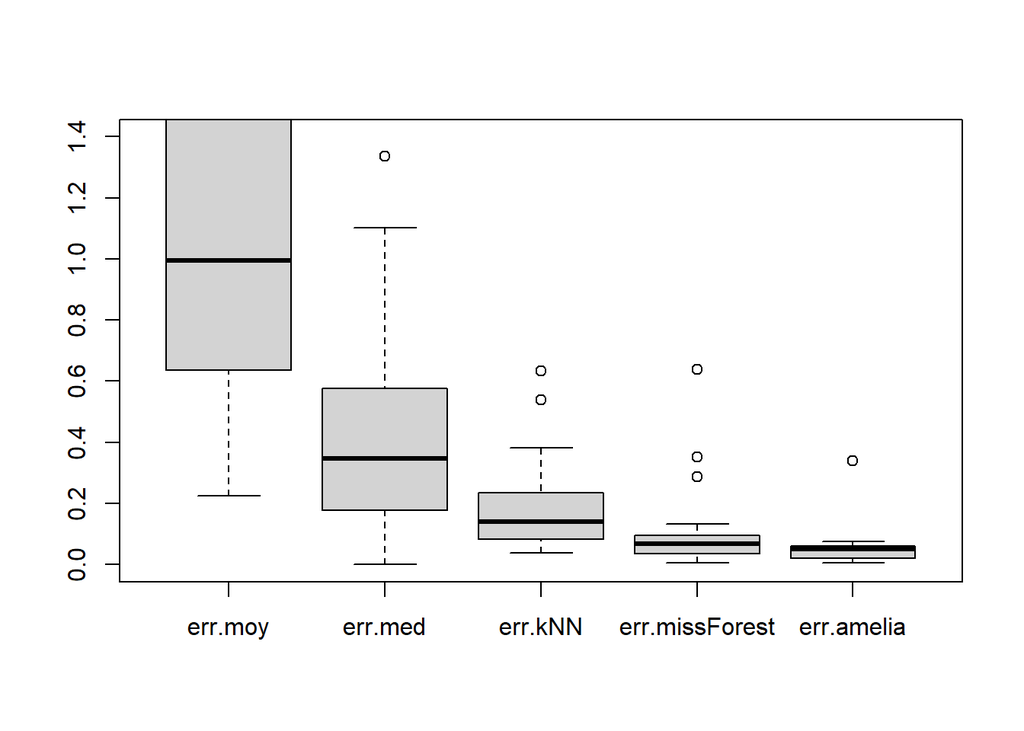

```r
# Erreurs de complétion sur l’échantillon test
boxplot(data.frame(err.moy, err.med, err.kNN, err.missForest,err.amelia),ylim=c(0,1.4))
```